# Basics IV: Data Visualizations Using ggplot

Steven Luke

2026-01-02

Go To Home Page

In this unit, we’re going to learn how to make graphs. The urge to present data in a pictorial format is an ancient one, and you are sure to find a primordial satisfaction in learning how to do so effectively.

[figure not shown]

# Why Present Data Visually?

What are the benefits of displaying data visually?

- *Your audience can understand it, and quickly.* A picture is attention-grabbing, and can be much more concise that text - it is worth a thousand words, they say.
- *You can understand it.* The act of deciding what information needs to be presented and how to most effectively present it forces you to understand your data better.
- *Aforementioned primordial satisfaction.*

# Variable Basics Review

Let’s take a moment to review what we know about variables. This will prove beneficial later.

1. Give an example of a ‘continuous’ variable.
2. How would a continuous variable be represented in R (number, factor, string)?
3. Give an example of a ‘categorical’ variable.
4. How would a categorical variable be represented in R (number, factor, string)?

# Video Tutorial: Types of Visualizations

https://byu.box.com/s/x26ypl54ngd2ikobqj74rblsou0w0zt9

# Types of Visualizations

There are many ways to present data visually, including but not limited to:

- Histogram
- Density Plot
- Scatter Plot
- Line Graph
- Bar Graph
- Box Plot
- Violin Plot
- Bubble Plot
- Heat Maps

## Histogram

A *histogram* has:

- **x-axis**: a continuous variable that you want to describe
- **y-axis**: a count of # of data points at each value of x-axis

It is used to:

- visualize *a single variable*
- see which values of a variable are most common.

[figure not shown]

Histogram (From [Wikimedia](https://upload.wikimedia.org/wikipedia/commons/c/c3/Histogram_of_arrivals_per_minute.svg))

## Density Plot

A *density plot* has:

- **x-axis**: a continuous variable that you want to describe
- **y-axis**: probability of a given value occurring in the data

It is used to:

- visualize *a single variable*
- see which values of a variable are most likely.

[figure not shown]

Density Plot (From [Wikimedia](https://upload.wikimedia.org/wikipedia/commons/8/8d/Reaction_time_density_plot.svg)

## Histograms & Density Plots

Histograms and Density plots are highly compatible and convey similar information.

They can be overlaid to make a nice graph.

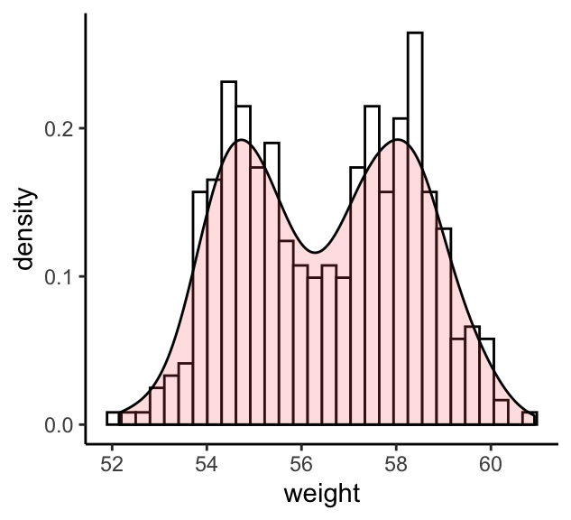

Source: [www.datanovia.com](https://www.datanovia.com/en/wp-content/uploads/dn-tutorials/ggplot2/figures/013-ggplot-histogram-geom_histogram-combine-density-and-histogram-1.png)

## Scatterplot

A *scatterplot* has:

- **x-axis**: a continuous variable (usually a predictor variable)
- **y-axis**: a continuous variable (usually the dependent variable)

It is used to:

- visualize *a relationship between 2 continuous variables*
- see how changes in one variable are related to changes in another.

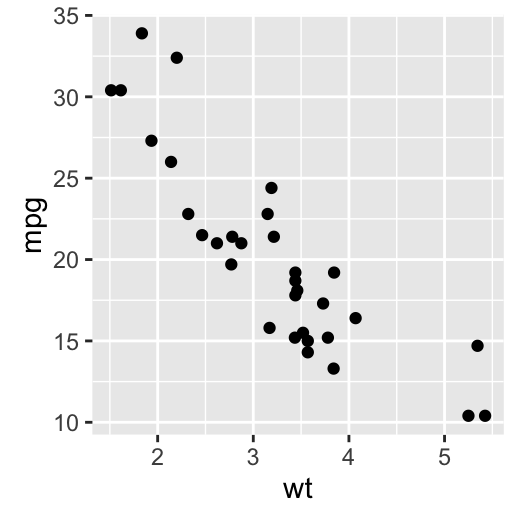

Scatterplot (From [sthda.com](http://www.sthda.com/sthda/RDoc/figure/ggplot2/ggplot2-scatter-plot-basic-graph-data-visualization-1.png))

A *scatterplot* also often includes:

- **a trendline**: a line that shows the trend of the relationship

This line might be:

- a free-flowing line that shows the overall trend in the data (unlimited degrees of freedom)
- a line or simple curve that reflects the results of a statistical analysis (limited degrees of freedom)

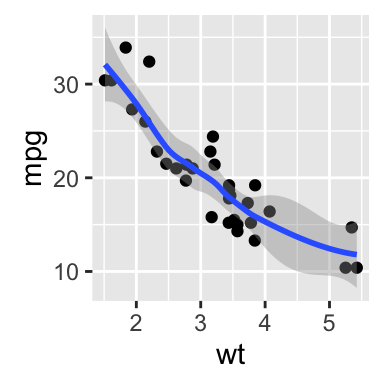

Scatterplot with trendline (From [sthda.com](http://www.sthda.com/sthda/RDoc/figure/ggplot2/ggplot2-scatter-plot-regression-lines-data-visualization-3.png))

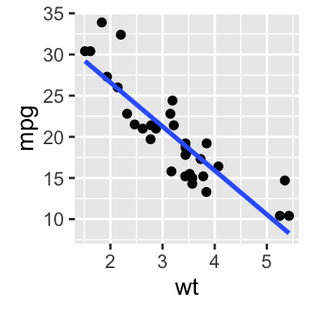

Scatterplot with linear trendline (From [sthda.com](http://www.sthda.com/sthda/RDoc/figure/ggplot2/ggplot2-scatter-plot-regression-lines-data-visualization-2.png))

## Line Graph

A *line graph* has:

- **x-axis**: A continuous variable (usually representing time or some other, similar variable)
- **y-axis**: a continuous variable (usually the dependent variable)

It is used to:

- visualize how one variable changes across time (or across some other continuous variable)

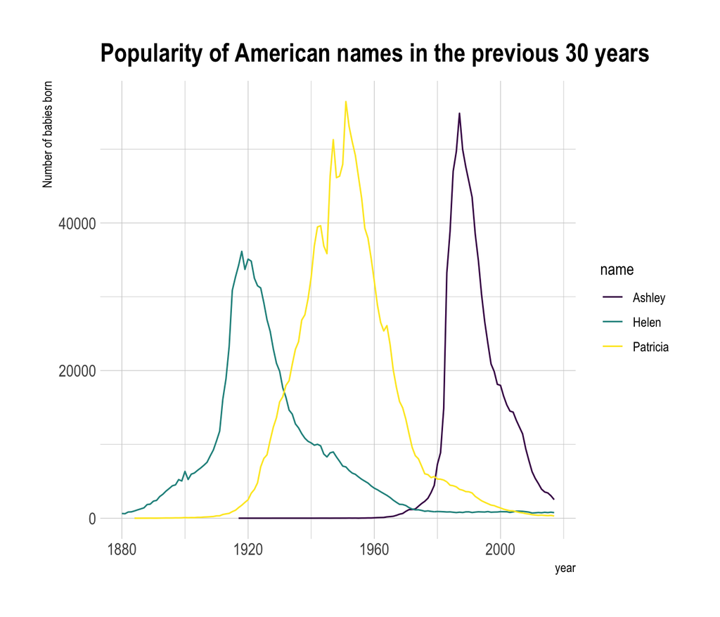

Line Chart (From [r-graph-gallery.com](https://r-graph-gallery.com/line-chart-several-groups-ggplot2_files/figure-html/thecode2-1.png))

## Bar Graph

A *bar graph* has:

- **x-axis**: 1 or more categorical variables (usually a predictor variable)
- **y-axis**: a continuous variable (usually the dependent variable)

It is used to:

- visualize a relationship between categorical variable(s) and a continuous variable
- show differences between groups

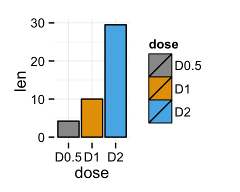

Bar Chart (From [sthda.com](http://www.sthda.com/sthda/RDoc/figure/ggplot2/ggplot2-barplot-multiple-groups-black-outline-data-visualization-1.png))

A *bar graph* often also has:

- **error bars**: whiskers on each bar

Error bars are used to:

- express the uncertainty of the measurement (“the *true* mean is somewhere in here”)
- show statistical significance (if the error bars of two conditions overlap, they are not statistically different)

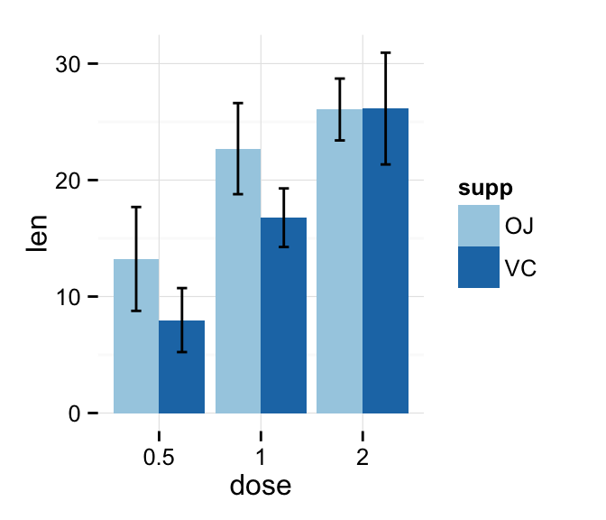

Bar Chart with Error Bars (From [sthda.com](http://www.sthda.com/sthda/RDoc/figure/ggplot2/ggplot2-barplot-with-error-bar-data-visualization-1.png))

## Box Plot

A *box plot* has:

- **x-axis**: a categorical grouping variables (usually a predictor variable)
- **y-axis**: a continuous variable (usually the dependent variable)

These axes can be switched.

What does a box-plot show?

- The horizontal line shows the median value for each group.
- The box encompasses the 25th to 75th percentile (i.e. the box represents 50% of the data points)
- The vertical lines extend to the minimum and max for the data (excluding outliers)
- The dots show outliers

A *box plot* is used to:

- show means and variability for multiple groups
- show differences between groups

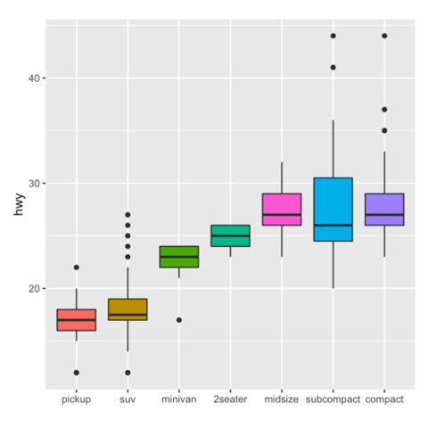

Box Plot (From [r-graph-gallery.com](https://r-graph-gallery.com/img/graph/267-reorder-a-variable-in-ggplot2_box.png))

## Violin Plot

A *violin plot* is a variation on the box plot.

Instead of using boxes and lines, it simply shows a sideways *density plot* for each group.

A violin plot and box plot can be combined for an extra informative (and classy) graph.

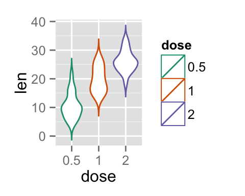

Violin Plot (From [r-graph-gallery.com](http://www.sthda.com/sthda/RDoc/figure/ggplot2/ggplot2-violin-plot-group-line-manual-color-data-visualization-2.png))

## Violin Plot & Box Plot

A *violin plot* and *box plot* can be combined for an extra informative (and classy) graph.

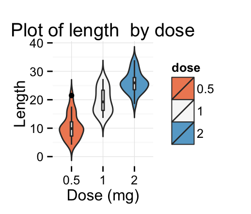

Violin Plot with Box Plot (From [r-graph-gallery.com](http://www.sthda.com/sthda/RDoc/figure/ggplot2/ggplot2-violin-plot-customized-box-plot-change-color-data-visualization-3.png))

## Bubble Plot

A *bubble plot* takes a variety of forms.

It is usually either:

- a simple grid (see below) where both axes are categorical variables
- some version of a scatterplot, where both axes are continuous.

The key feature of a bubble plot is that each point is scaled to reflect the value of some third variable

It is used to:

- show how some third continuous variable interacts with 2 other variables

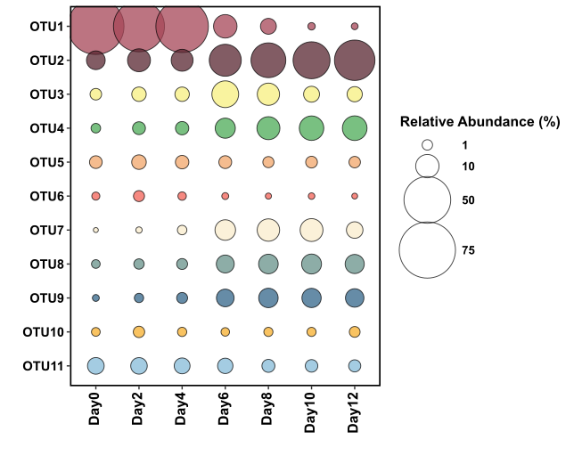

Bubble Plot (From [jkzorz.github.io](https://jkzorz.github.io/assets/For_blog_bubble.png))

A *bubble plot* takes a variety of forms.

It is usually either:

- a simple grid (see below) where both axes are categorical variables
- some version of a scatterplot, where both axes are continuous.

The key feature of a bubble plot is that each point is scaled to reflect the value of some third variable

It is used to:

- show how some third continuous variable interacts with 2 other variables

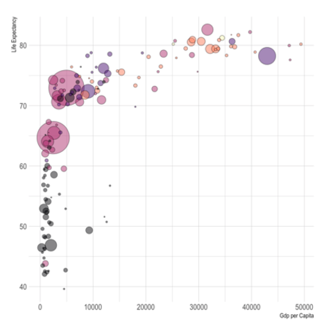

Bubble Plot (From [r-graph-gallery.com](https://r-graph-gallery.com/img/graph/320-the-basis-of-bubble-plot3.png))

## Heat Map

A *heat map* is another way to represent a 3rd variable

The difference is that the bubble plot uses size to represent some third variable’s relationship to two variables, while a heat map uses color. The color usually scales from ‘cool’ colors (blues) to ‘hot’ colors (reds) - hence the name *heat map*.

Like a bubble plot, a heat map is usually either:

- a simple grid where both axes are categorical variables
- some version of a scatterplot, where both axes are continuous.

[figure not shown]

Heatmap showing eye tracking data (From [i-insider.com](https://i.insider.com/53c67fa669beddf90e51b84c?width=1000&format=jpeg&auto=webp))

some other examples can be found here: (https://r-graph-gallery.com/heatmap.html)

## Different Types of Graphs (Checklist items 5-10)

Identify each of the graphs below. What kind is it?

##### Graph 5

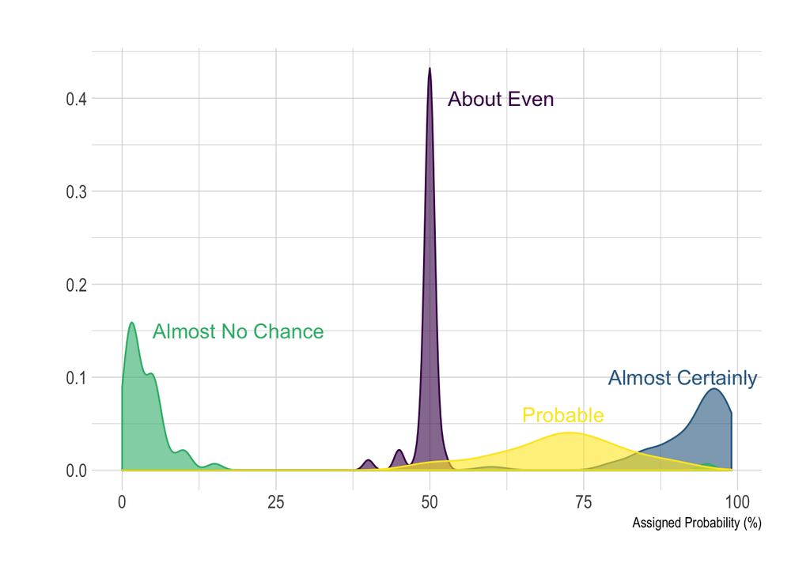

Easy, right?

##### Graph 6

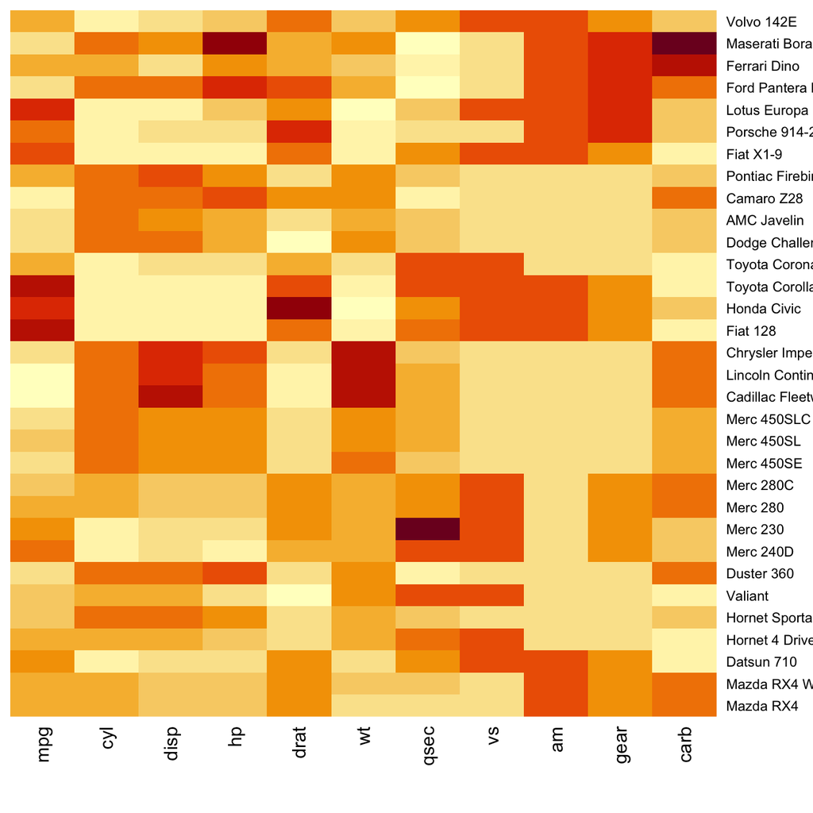

This one’s easy

##### Graph 7

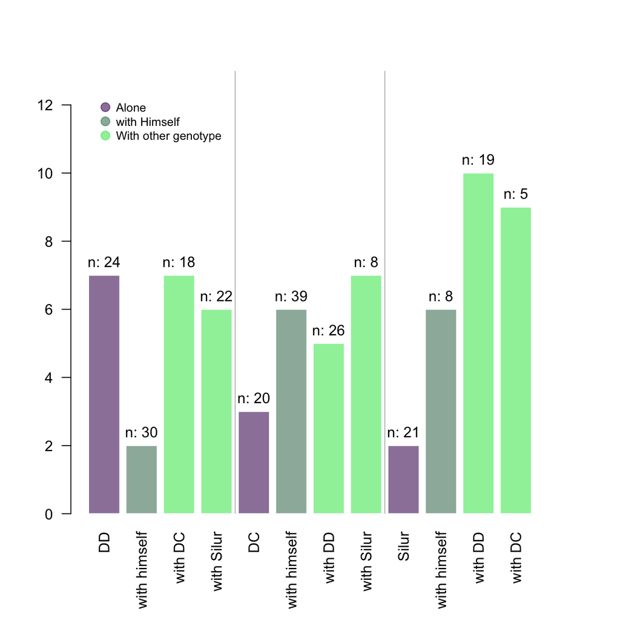

Here’s Another

##### Graph 8

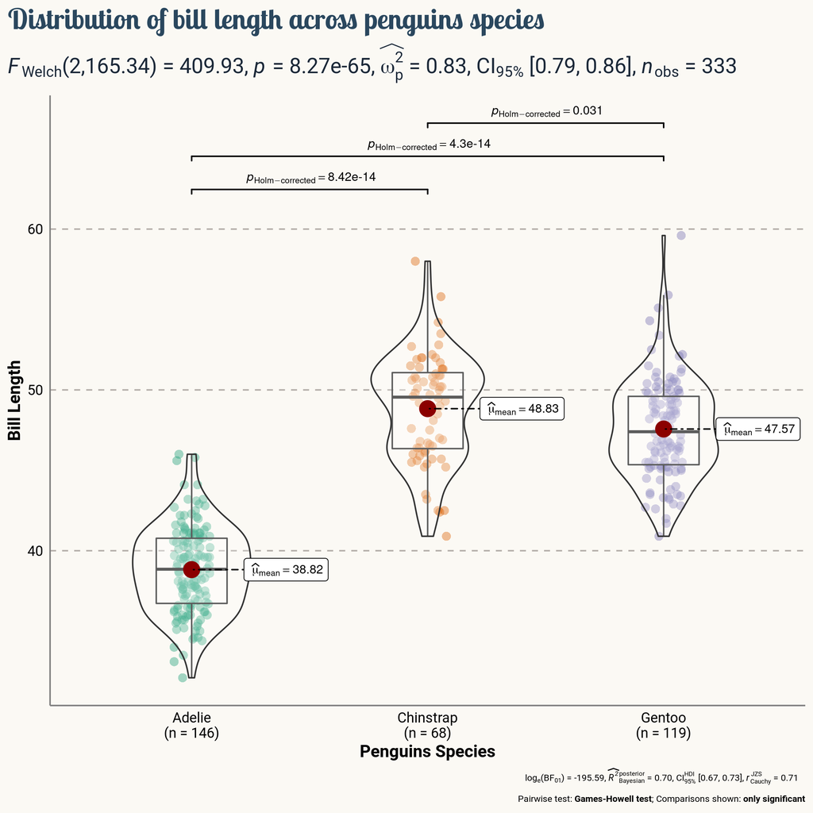

I think this might be a combination of two plot types

##### Graph 9

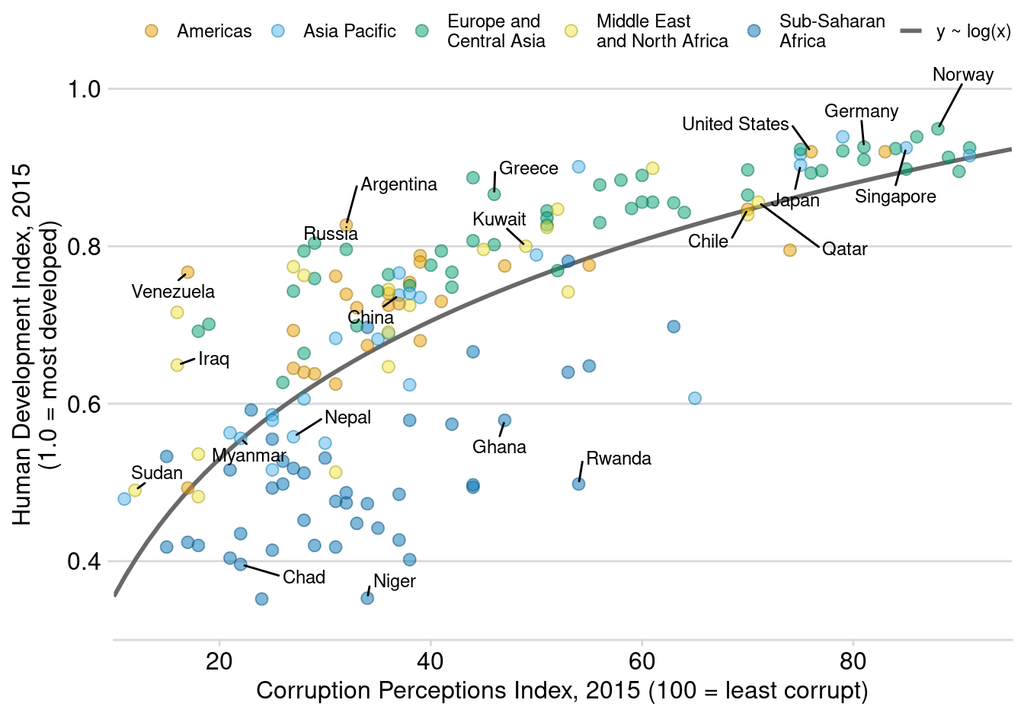

Now this one

##### Graph 10

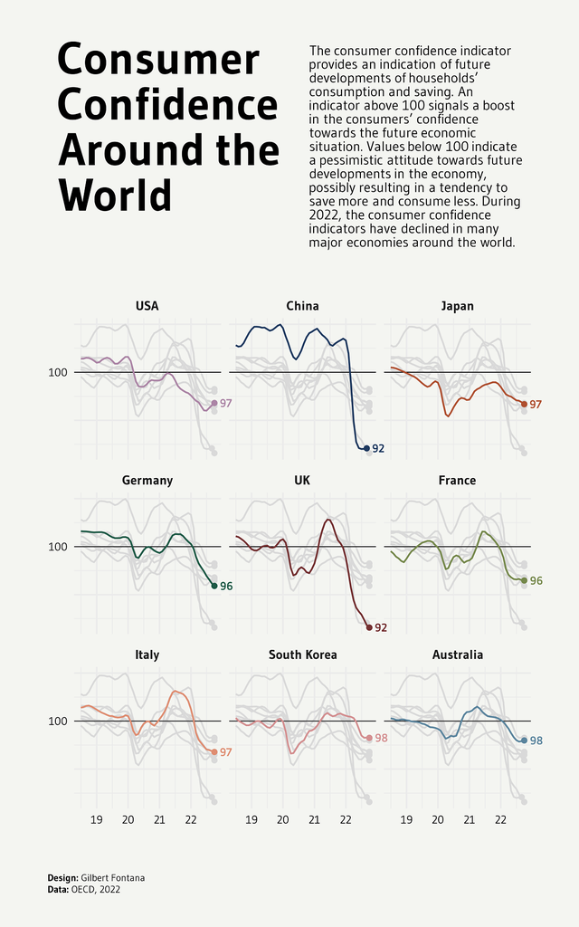

How’s YOUR consumer confidence

All example graphs from r-graph-gallery.com

## And Many More

11. Find a graph on the internet that is NOT of the same type as the ones we’ve discussed. Include a link, and describe when you think a graph of this type would be handy.

## When to use different graphs

12. In R Markdown, make a table like the one below. But don’t leave it empty! Categorize the following types of graphs by placing them in the correct column to complete the table:
- Line Graph
- Heat Map
- Density Plot
- Bubble Plot
- Histogram
- Violin Plot
- Box Plot
- Bar Graph
- Scatterplot

##### Number and Types of Variables for Different Graphs

| One continuous | Two continuous | One categorical, one continuous | Three, at least one continuous |
| --- | --- | --- | --- |
| ? |  |  |  |
| ? |  |  |  |
| ? |  |  |  |

## Picking a graph based on data

13. Consider the example data below. What type of graph would you want to use here?

| Participant | Condition | Observation |
| --- | --- | --- |
| 1 | A | 5 |
| 2 | A | 2 |
| 3 | A | 7 |
| 4 | A | 4 |
| 5 | A | 1 |
| 6 | B | 10 |
| 7 | B | 4 |
| 8 | B | 10 |
| 9 | B | 5 |
| 10 | B | 9 |

14. Now consider this data. What type of graph might you want to use here?

| Musher | Checkpoint | Time |
| --- | --- | --- |
| Jerry Sousa | 1 | 243 |
| Jerry Sousa | 2 | 176 |
| Jerry Sousa | 3 | 304 |
| Jerry Sousa | 4 | 201 |
| Melissa Owens | 1 | 215 |
| Melissa Owens | 2 | 421 |
| Melissa Owens | 3 | 334 |
| Melissa Owens | 4 | 220 |

For the next three questions, we will look at the mtcars data set, which comes pre-loaded in R. To learn more about this data set, check the help page (*?mtcars*)

```r
select(mtcars, c(1:6)) %>% # We'll just look at the first 6 columns
  knitr::kable()
```

|  | mpg | cyl | disp | hp | drat | wt |
| --- | --- | --- | --- | --- | --- | --- |
| Mazda RX4 | 21.0 | 6 | 160.0 | 110 | 3.90 | 2.620 |
| Mazda RX4 Wag | 21.0 | 6 | 160.0 | 110 | 3.90 | 2.875 |
| Datsun 710 | 22.8 | 4 | 108.0 | 93 | 3.85 | 2.320 |
| Hornet 4 Drive | 21.4 | 6 | 258.0 | 110 | 3.08 | 3.215 |
| Hornet Sportabout | 18.7 | 8 | 360.0 | 175 | 3.15 | 3.440 |
| Valiant | 18.1 | 6 | 225.0 | 105 | 2.76 | 3.460 |
| Duster 360 | 14.3 | 8 | 360.0 | 245 | 3.21 | 3.570 |
| Merc 240D | 24.4 | 4 | 146.7 | 62 | 3.69 | 3.190 |
| Merc 230 | 22.8 | 4 | 140.8 | 95 | 3.92 | 3.150 |
| Merc 280 | 19.2 | 6 | 167.6 | 123 | 3.92 | 3.440 |
| Merc 280C | 17.8 | 6 | 167.6 | 123 | 3.92 | 3.440 |
| Merc 450SE | 16.4 | 8 | 275.8 | 180 | 3.07 | 4.070 |
| Merc 450SL | 17.3 | 8 | 275.8 | 180 | 3.07 | 3.730 |
| Merc 450SLC | 15.2 | 8 | 275.8 | 180 | 3.07 | 3.780 |
| Cadillac Fleetwood | 10.4 | 8 | 472.0 | 205 | 2.93 | 5.250 |
| Lincoln Continental | 10.4 | 8 | 460.0 | 215 | 3.00 | 5.424 |
| Chrysler Imperial | 14.7 | 8 | 440.0 | 230 | 3.23 | 5.345 |
| Fiat 128 | 32.4 | 4 | 78.7 | 66 | 4.08 | 2.200 |
| Honda Civic | 30.4 | 4 | 75.7 | 52 | 4.93 | 1.615 |
| Toyota Corolla | 33.9 | 4 | 71.1 | 65 | 4.22 | 1.835 |
| Toyota Corona | 21.5 | 4 | 120.1 | 97 | 3.70 | 2.465 |
| Dodge Challenger | 15.5 | 8 | 318.0 | 150 | 2.76 | 3.520 |
| AMC Javelin | 15.2 | 8 | 304.0 | 150 | 3.15 | 3.435 |
| Camaro Z28 | 13.3 | 8 | 350.0 | 245 | 3.73 | 3.840 |
| Pontiac Firebird | 19.2 | 8 | 400.0 | 175 | 3.08 | 3.845 |
| Fiat X1-9 | 27.3 | 4 | 79.0 | 66 | 4.08 | 1.935 |
| Porsche 914-2 | 26.0 | 4 | 120.3 | 91 | 4.43 | 2.140 |
| Lotus Europa | 30.4 | 4 | 95.1 | 113 | 3.77 | 1.513 |
| Ford Pantera L | 15.8 | 8 | 351.0 | 264 | 4.22 | 3.170 |
| Ferrari Dino | 19.7 | 6 | 145.0 | 175 | 3.62 | 2.770 |
| Maserati Bora | 15.0 | 8 | 301.0 | 335 | 3.54 | 3.570 |
| Volvo 142E | 21.4 | 4 | 121.0 | 109 | 4.11 | 2.780 |

15. If I wanted to visualize the relationship between **mpg** (Miles per gallon) and **wt** (Weight), what sort of graph should I make?
16. If I wanted to visualize the difference in **hp** (horsepower) between all the different *Merc* models, what would be the best graph to use?
17. If I wanted to visualize the single variable **cyl** (number of cylinders) to see which values were common and which uncommon, what would be the best graph to use?

# Video Tutorial: Basics of ggplot & Making Different Types of Plots

Part 1: https://byu.box.com/s/k3y4l9lczurhr8eo8em5q4ts75zlizhi  
Part 2: https://byu.box.com/s/b3ck5mc9fid22gq5n01fwu6akmrmj1gw

# Basics of ggplot

Every time you create a plot with ggplot, follow these 7 steps:

1. Call the ggplot function and specify what data to use
2. Add axis ‘aesthetics’ using aes() to lay out the plot area
3. Add a plot layer
4. Customize the plot layer
5. Add more layers as needed
6. Finalize the plot
7. Save the plot

## Step 1: Call the ggplot function and specify what data to use

```r
ggplot(data = diamonds)
```

Don’t bother to run this yet, you won’t get anything.

**PRO TIP:** In R Markdown, create a new code chunk for each plot you make and keep other code out of these chunks as much as possible. This way, you can easily move plots around within your document and customize them as desired.